# Differential abundance: CSF proteome in Alzheimer’s disease (PXD016278)

## Handling of missing values

Missing values are more frequent in controls than in AD after adjusting for batch and age (see QC report), so their treatment can bias the AD vs. control comparison. Three treatments were compared on the same model (`~ group + batch + age + sex`): limma on observed values only, limma after left-censored imputation (down-shifted normal, 1.8 SD shift, 0.3 SD width), and proDA, which models the probability of a value being missing as a function of intensity without imputing.

Table 1: Protein groups with FDR < 5% by method and direction of change.

| method | higher in AD | lower in AD | total |
| --- | --- | --- | --- |
| imputed | 225 | 65 | 290 |
| observed | 181 | 78 | 259 |
| proda | 178 | 66 | 244 |

Table 2: Agreement of each alternative with proDA (FDR < 5%).

| method | both | proDA only | alternative only |
| --- | --- | --- | --- |
| observed | 239 | 5 | 20 |
| imputed | 201 | 43 | 89 |

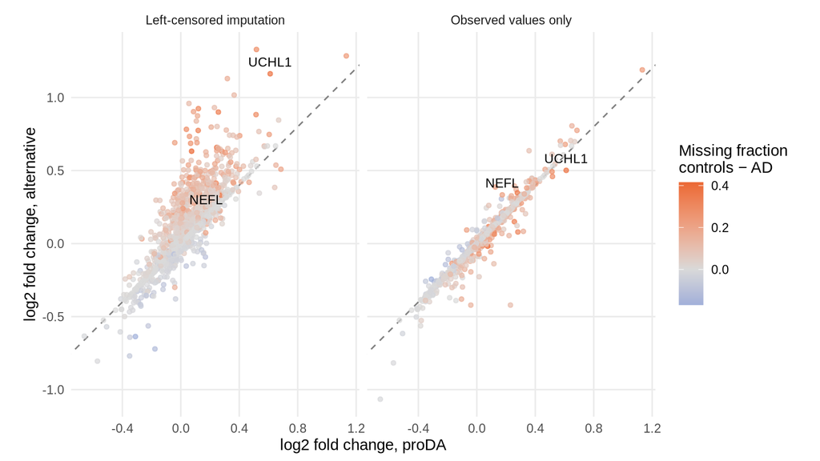

Figure 1: AD vs control log2 fold change of each alternative against proDA. Each point is a protein group; colour is the difference in missing-value fraction between controls and AD. Dashed line: identity.

Left-censored imputation inflates effect sizes across the proteome, most strongly for protein groups with more missing values in controls, and changes the set of significant protein groups substantially. Limma on observed values agrees closely with proDA; discordant protein groups lie near the FDR threshold with near-identical fold changes. proDA is used for the main analysis; limma on observed values with sample quality weights is reported as a sensitivity analysis.

## Differential abundance

Main model: proDA, ~group + site + age + sex, AD vs control, Benjamini-Hochberg FDR. Site (rather than MS batch) is used because each site was measured in a single batch and site separates Kiel (controls only) from Magdeburg.

Table 3: Protein groups by result tier and direction of change.

| tier | higher in AD | lower in AD |
| --- | --- | --- |
| barrier-robust | 45 | 6 |
| main model only | 147 | 61 |
| not significant | 622 | 436 |

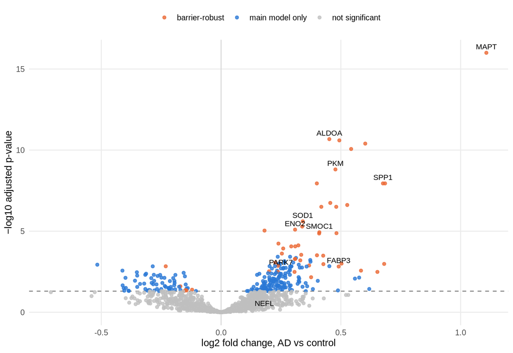

Figure 2: Volcano plot, AD vs control (main model). Barrier-robust protein groups remain significant after adjusting for the plasma-protein score. Adjusted p-values below 1e-16 are shown at 1e-16.

### Positive controls

Table 4: Known CSF markers of AD. MAPT is partly circular, since diagnosis is defined from CSF tau.

| gene | tier | log2FC | p_adj | p_adj_plasma_adjusted |
| --- | --- | --- | --- | --- |
| MAPT | barrier-robust | 1.11 | 0.0e+00 | 0.00000 |
| SOD1 | barrier-robust | 0.34 | 2.5e-06 | 0.00049 |
| PARK7 | main model only | 0.25 | 2.0e-03 | 0.11000 |
| UCHL1 | barrier-robust | 0.58 | 2.7e-03 | 0.02900 |
| NEFL | not significant | 0.18 | 6.7e-01 | 0.77000 |

### Sensitivity analyses

Table 5: Agreement of each sensitivity analysis with the main model: correlation of log2 fold changes, and significant protein groups shared, lost and gained.

| analysis | r_logFC | n_significant | shared | lost | gained |
| --- | --- | --- | --- | --- | --- |
| limma_arrayweights | 0.959 | 313 | 246 | 13 | 67 |
| without_blood_flag | 0.999 | 261 | 252 | 7 | 9 |
| plasma_adjusted | 0.842 | 53 | 51 | 208 | 2 |
| renormalized | 0.998 | 251 | 209 | 50 | 42 |

Results are unchanged without the runs flagged for blood contamination and after renormalization (the renormalized list differs only near the FDR threshold, as all fold changes shift by the small diagnosis-associated offset seen in QC). Limma with sample weights recovers the same effects with more power. Adjusting for the plasma-protein score, which is lower in AD, reduces the significant set to a core of protein groups. The score admits three readings that these data cannot separate: a confounder (blood–CSF barrier permeability), a mediator of disease effects, or a compositional effect of normalization. On the last reading, when many brain-derived proteins rise, the relative share of plasma proteins falls; consistent with it, 67% of all protein groups correlate negatively with the score, and the plasma adjustment shrinks the fold change of proteins higher in AD by a median of 42%. Adjusting for the score may then remove part of the disease signal. Both tiers are reported, and the barrier-robust core is read as a conservative lower bound, not as the specific signal.

Table 6: Direction of change by tier. Decreases in AD depend more on the plasma-protein balance than increases.

| tier | direction | n | % of tier |
| --- | --- | --- | --- |
| barrier-robust | higher in AD | 45 | 88 |
| barrier-robust | lower in AD | 6 | 12 |
| main model only | higher in AD | 147 | 71 |
| main model only | lower in AD | 61 | 29 |

### Barrier-robust core

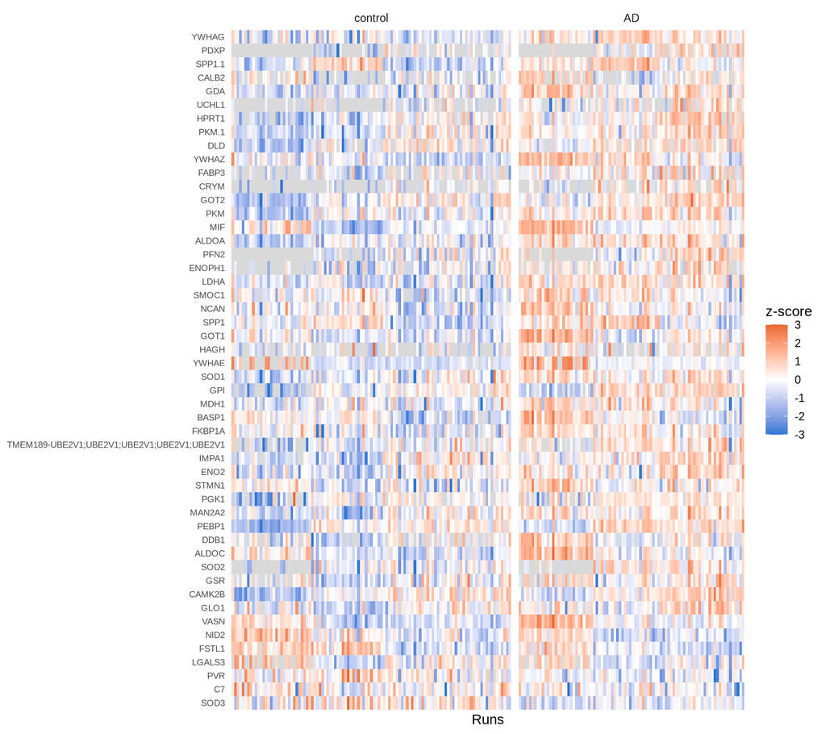

Figure 3: Barrier-robust protein groups, excluding MAPT (circular): z-scored log2 intensities per run (grey: missing), runs ordered by diagnosis and site, protein groups ordered by log2 fold change.

The core (50 protein groups; MAPT is excluded because diagnosis is defined from CSF tau) is dominated by glycolytic enzymes (ALDOA, ALDOC, PKM, LDHA, GPI, ENO2, PGK1), 14-3-3 proteins (YWHAZ, YWHAG, YWHAE) and established CSF markers of AD (SOD1, UCHL1, SMOC1, SPP1, FABP3), mostly cytosolic proteins higher in AD. Glycolytic enzymes in CSF most likely indicate release from damaged cells rather than a change in metabolism. The glycolytic signature was also reported in the original study.

## Diagnostic classifier

An elastic-net logistic regression (α = 0.5, penalty chosen by inner 5-fold cross-validation, `lambda.1se`) classifies AD vs control from the proteome. The missing-value filter (≤ 20% missing), protein selection, imputation of missing values (half the training minimum) and scaling are learned within each training split. MAPT is excluded, as diagnosis is defined from CSF tau, and Kiel is excluded, as its controls are age-mismatched and include no AD. Performance is estimated by 10 × 5-fold nested cross-validation and by leave-one-site-out validation, against an age + sex baseline.

A median of 978 protein groups passed the missing-value filter in each training split.

Table 7: Area under the ROC curve. Nested CV: out-of-fold predictions averaged over 10 repetitions, with DeLong 95% confidence interval; in brackets, the range of AUC across repetitions. Leave-one-site-out: one model per held-out site.

| validation | n | AUC proteome | AUC age + sex |
| --- | --- | --- | --- |
| Nested CV (10 × 5-fold) | 181 | 0.90 (95% CI 0.85–0.95) [0.83–0.90] | 0.61 (95% CI 0.52–0.69) |
| Held-out site: Berlin | 83 | 0.74 | 0.51 |
| Held-out site: Magdeburg | 38 | 0.88 | 0.71 |
| Held-out site: Sweden | 60 | 0.73 | 0.59 |

Table 8: Performance of the averaged out-of-fold predictions at a fixed probability threshold of 0.5.

| threshold | sensitivity | specificity | ppv | npv |
| --- | --- | --- | --- | --- |
| 0.5 | 0.81 | 0.83 | 0.82 | 0.82 |

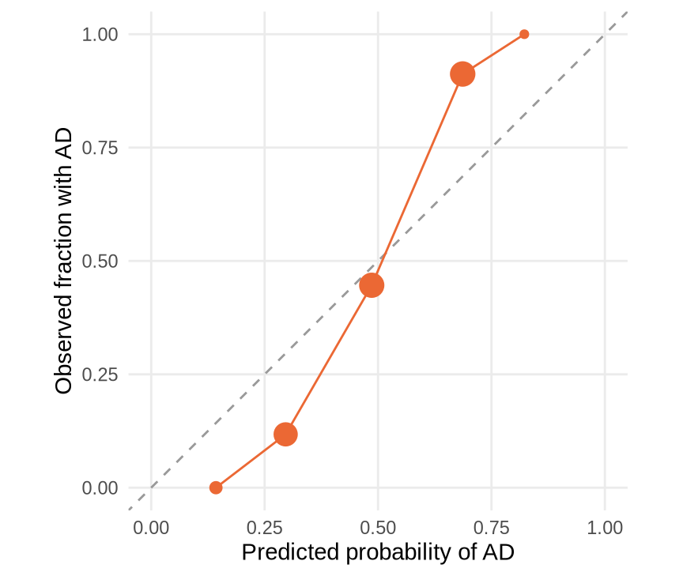

Figure 4: Calibration of the averaged out-of-fold predictions: observed fraction of AD by bin of predicted probability (point size: number of samples). Dashed line: perfect calibration.

Calibration slope 2.67 and intercept 0.02 (ideal: 1 and 0); a slope below 1 means predictions are too extreme, above 1 too conservative. The proteome outperforms the age + sex baseline (paired DeLong test, p = <1e-04).

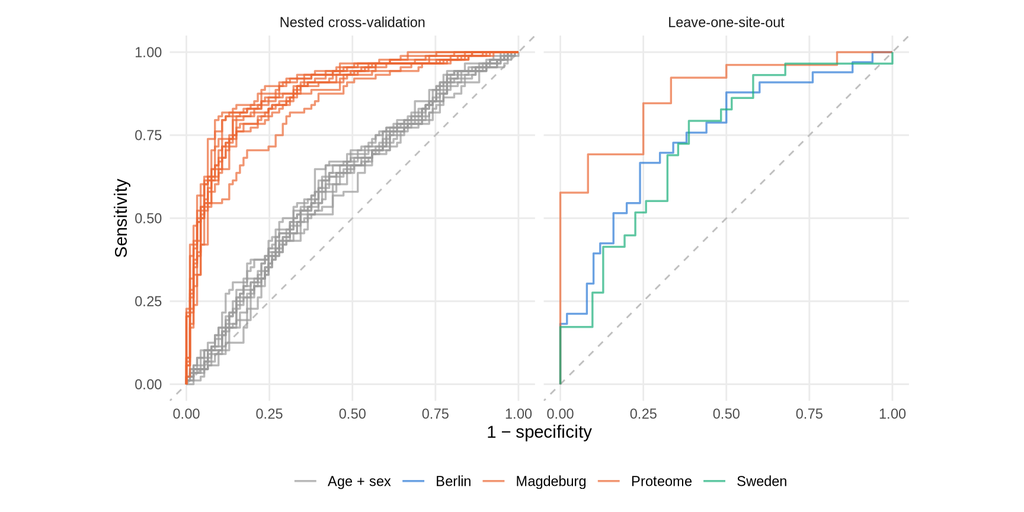

Figure 5: ROC curves. Left: nested cross-validation, one line per repetition (proteome) and age + sex baseline. Right: leave-one-site-out, one line per held-out site.

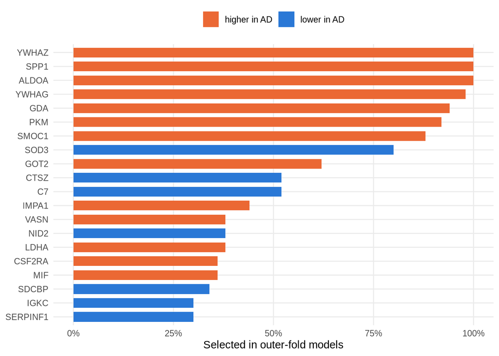

Figure 6: Selection stability: fraction of the 50 outer-fold models selecting each protein group (top 20). Colour: sign of the mean coefficient.

The proteome discriminates AD from controls well beyond age and sex. Across sites, performance is maintained for Magdeburg and lower for Berlin and Sweden. Berlin is the largest cohort, so the model is trained on fewer samples when it is held out, and its controls are mostly patients with other neurological diagnoses. Sweden quantifies fewer proteins: many protein groups selected on the other two sites are frequently missing there and are imputed from the training minimum. When the missing-value filter was computed on all samples, test site included, Sweden reached 0.86; the lower value is the honest estimate of transfer to a new site. The most stable predictors (14-3-3 proteins, glycolytic enzymes, SPP1, SMOC1) are the same proteins as the barrier-robust core of the differential abundance analysis; both analyses use the same samples, so this is consistency rather than independent confirmation. The next section quantifies how much of this signal is explained by the CSF biomarkers that define the diagnosis.

## Circularity of the diagnostic label

Diagnosis is biochemical: AD requires high CSF tau and low amyloid, with the amyloid measure and thresholds differing by site. Every AD case has t-tau above 400 pg/ml, so any protein that rises with neurodegeneration is associated with the label by construction. t-tau and Aβ42 are the only biomarkers measured at all three sites with AD cases (n = 181; p-tau is missing in Berlin and Aβ42/40 in Sweden). The analysis uses the barrier-robust core without MAPT (50 protein groups), summarised as a signed score: the mean z-score across the core, with proteins lower in AD inverted, so that higher is more AD-like.

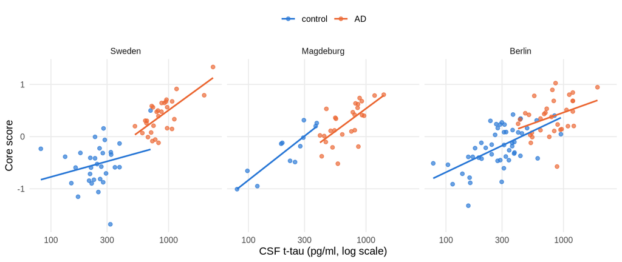

Figure 7: Core score against CSF t-tau, by site. Lines: linear fit within each diagnostic group. The score rises with t-tau with a similar slope in controls and AD.

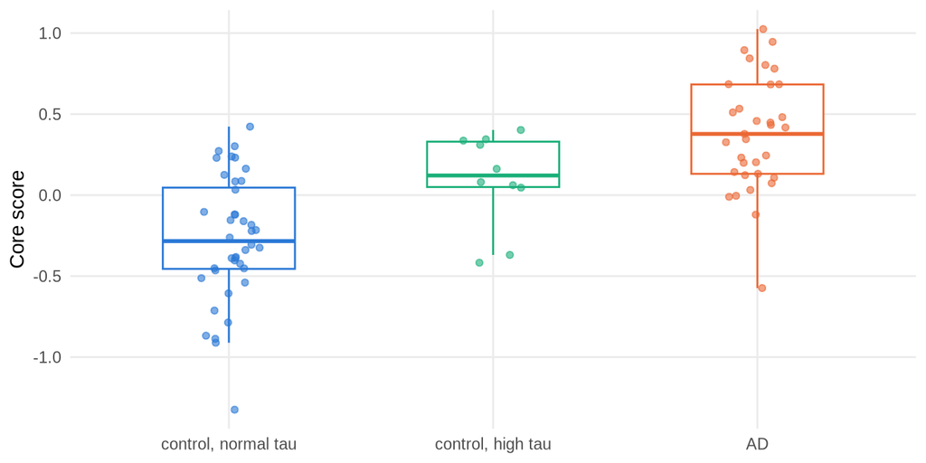

Figure 8: Berlin: core score in controls with t-tau below 400 pg/ml, controls with t-tau in the AD range, and AD.

Table 9: Association of the core score with the CSF biomarkers that define the diagnosis. Score estimates are in SD units; slopes are per doubling of t-tau. All models adjust for age and sex, and for site where more than one site is included.

| Analysis | n | Estimate | p |
| --- | --- | --- | --- |
| t-tau slope within AD | 88 | 0.36 | <1e-04 |
| t-tau slope within controls | 93 | 0.32 | <1e-04 |
| AD effect, unadjusted (3 sites) | 181 | 0.67 |  |
| AD effect, adjusted for t-tau (3 sites) | 181 | 0.12 | 0.17 |
| AD effect, adjusted for t-tau (Berlin) | 83 | 0.14 | 0.22 |
| Berlin: high-tau controls vs normal-tau controls | 83 | 0.39 | 0.0031 |
| Berlin: high-tau controls, fraction of AD effect | 83 | 0.60 (95% CI 0.27–0.94) |  |
| Berlin AD: Spearman correlation with MMSE | 33 | -0.35 | 0.046 |
| t-tau + Aβ42 + site predicting the label (CV AUC) | 181 | 0.98 (range 0.95–0.99) |  |

The core behaves as a continuous marker of neurodegeneration rather than of diagnosis. The score rises with t-tau within AD and within controls, with similar slopes, and individual core proteins track t-tau within each group (26 of 50 in AD, 27 in controls; FDR < 5%). In Berlin, controls with t-tau in the AD range lie between controls with normal tau and AD, but they also have less tau than AD (median 466 vs 804 pg/ml). Adjusting for t-tau reduces the AD effect on the score by 83%, to a non-significant value, and no core protein retains an AD effect at FDR < 5%. Since the label combines high tau with low amyloid, the tau-adjusted AD effect mainly reflects amyloid status: there is no evidence that the core tracks amyloid beyond tau, although the confidence interval does not exclude a small effect. Adjustment for a covariate measured with error tends to under-adjust, so the share explained by tau is, if anything, underestimated.